# BISR: dynamic summary

Date: 2017-02-15

## Legend

The column `covariance` contains four ways in which the association between processes can be reported:  
- `Correlation` = correlation , estimated in Mplus  
- `Correlation CI` = Confidence intervals estimated in Mplus  
- `Covariance` = raw covariance  
- `Fisher's R` = correlation, computed outside of Mplus using Fisher’s transform from raw variances and covariances

Note: cases in which restricted (co)variances or insufficient decimals prevent the computation of correlations are marked by `---`

**Raw covariance** and **estimated correlations** are reported in the form : **`est(se) pval star`**,where  
- `est` is the covariance estimate on the original metric  
- `se` is the standard error on the original metric  
- `pval` is the p-value associated with the raw covariance  
- `star` is significance indicator associated with corresponding covariance estimate, with `.`, `*`, `**`, and `***` indicating significance at `.10`, `.05`, `.01`, and `.001` alpha levels, respectively

**Confidence intervals** for estimated correlations are reported in the form: **`(low,high)`**,where  
- `low` - bottom boundry of the 95% confidence interval - `high` - top boundry of the 95% confidence interval

**Computed correlations** are reported in the form: **`est(low, high)`**, where  
- `est` is the correlation coefficient computed from raw (co)variances using Fisher transfrom  
- `low` and `high` are the 95% confidence intervals associated with the computed correlations

# Dynamic Summary

|  | domain | study | subgroup | model_type | physical | cognitive | N | covariance | Levels | Slopes | Residuals |
| --- | --- | --- | --- | --- | --- | --- | --- | --- | --- | --- | --- |
| 1 | mental status | hrs | female | a | pef | serial7 | 715 | Correlation | --- | --- | --- |
| 2 | mental status | hrs | female | a | pef | serial7 | 715 | Correlation CI | --- | --- | --- |
| 3 | mental status | hrs | female | a | pef | serial7 | 715 | Covariance | 16.89(308.48), p=.96 | .21(16.54), p=.99 | .29( .30), p=.33 |
| 4 | mental status | hrs | female | a | pef | serial7 | 715 | Fisher's R | .54( .49, .59) | .19( .12, .26) | .00(-.07, .07) |
| 5 | mental status | hrs | female | aeh | pef | serial7 | 715 | Correlation | --- | --- | --- |
| 6 | mental status | hrs | female | aeh | pef | serial7 | 715 | Correlation CI | --- | --- | --- |
| 7 | mental status | hrs | female | aeh | pef | serial7 | 715 | Covariance | 7.26(312.34), p=.98 | .20(16.59), p=.99 | .20( .30), p=.50 |
| 8 | mental status | hrs | female | aeh | pef | serial7 | 715 | Fisher's R | .28( .21, .34) | .18( .11, .25) | .00(-.07, .07) |
| 9 | mental status | hrs | female | aehplus | pef | serial7 | 4608 | Correlation | .13( .03), p&lt;.01 *** | .38( .13), p&lt;.01 ** | -.02( .02), p=.22 |
| 10 | mental status | hrs | female | aehplus | pef | serial7 | 4608 | Correlation CI | ( .08, .19) | ( .12, .63) | (-.06, .02) |

[output cut: 1826 more lines]

# Forest plots

## memory

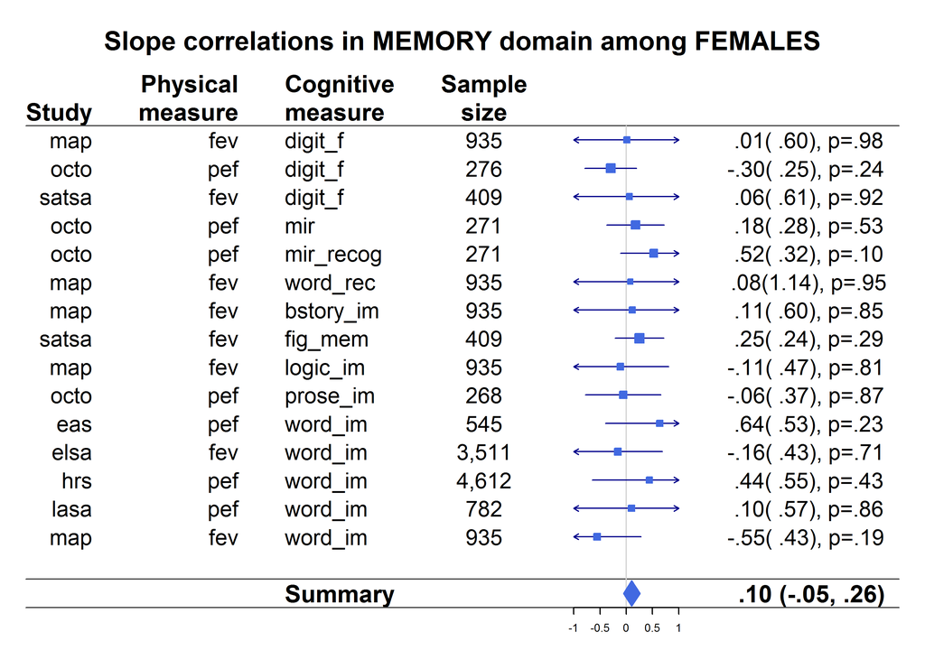

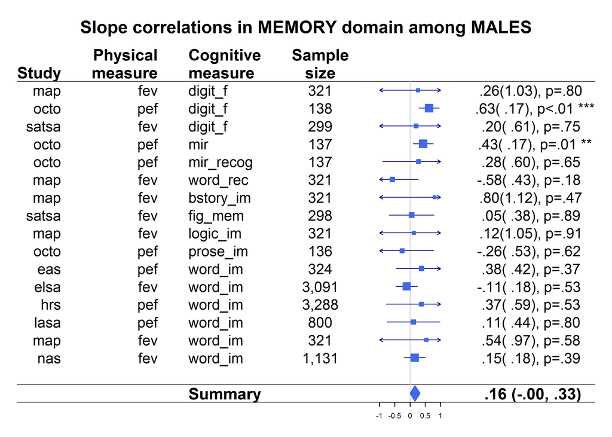

## mental status

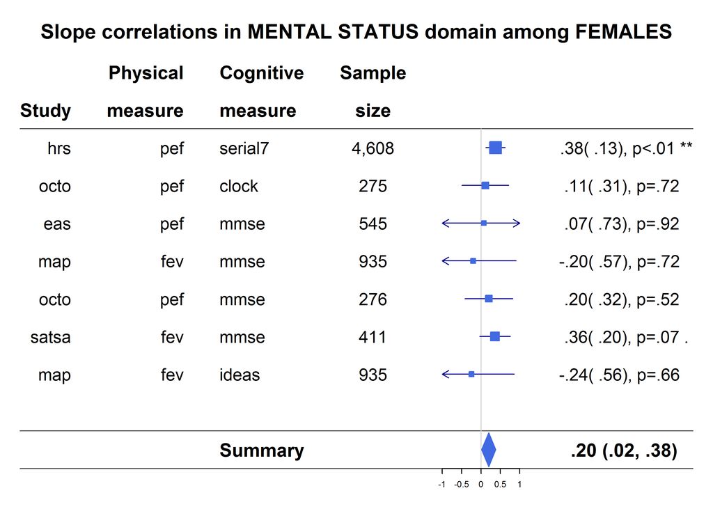

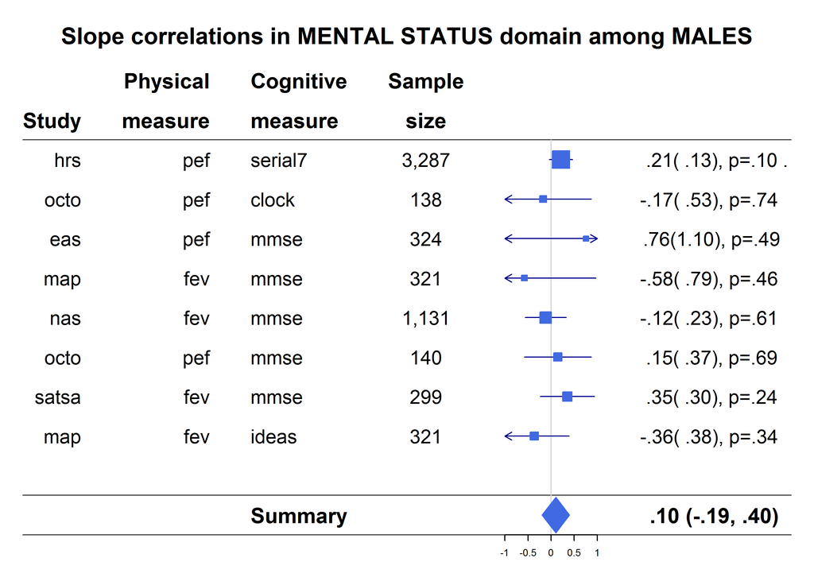

## delayed/working memory

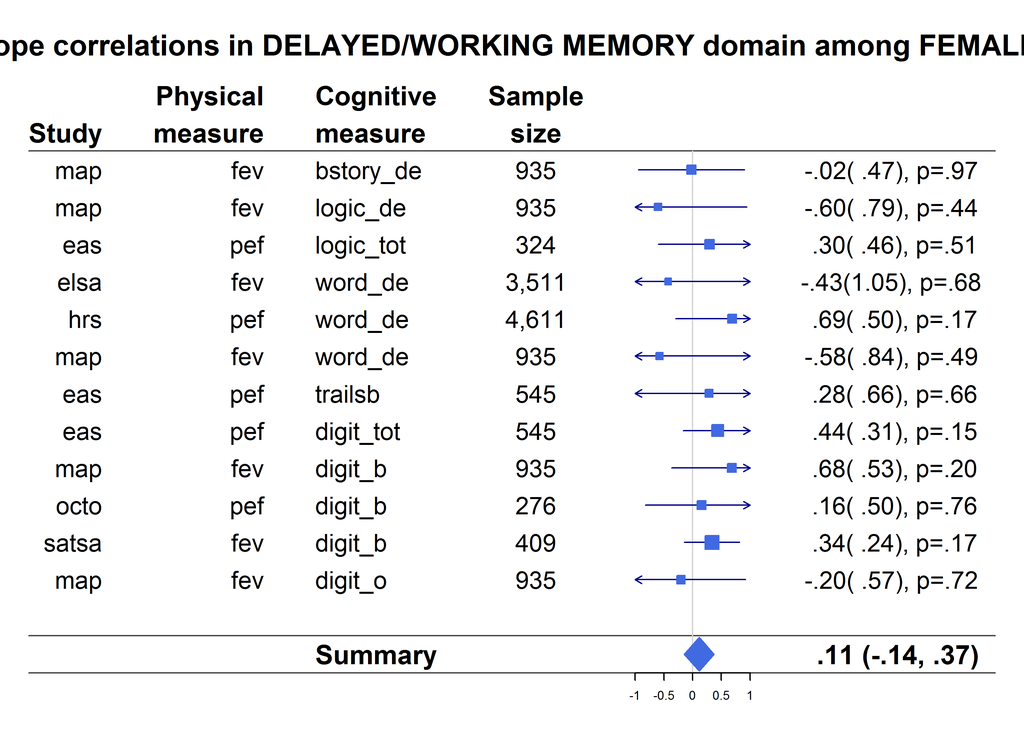

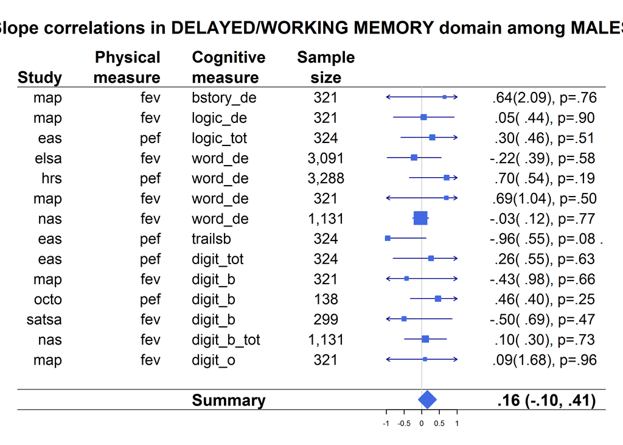

## verbal knowledge

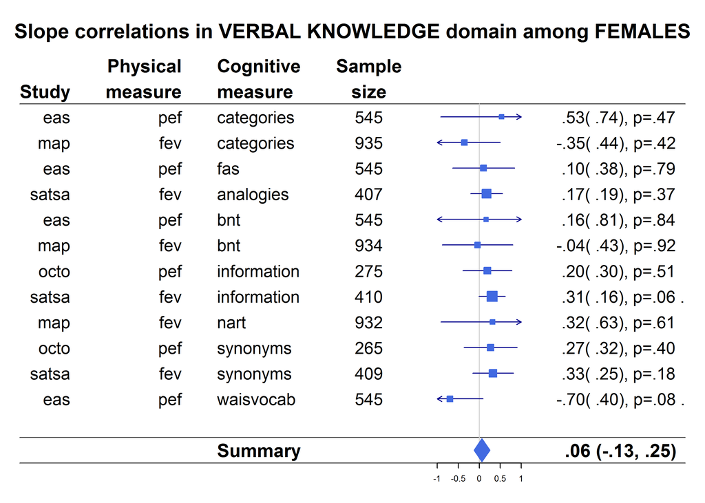

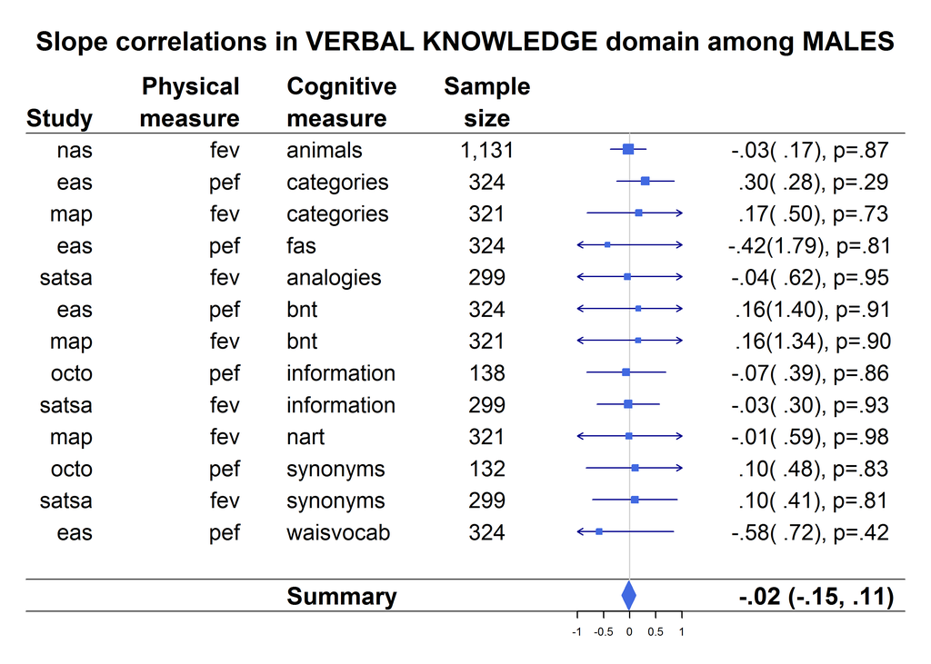

## visualization

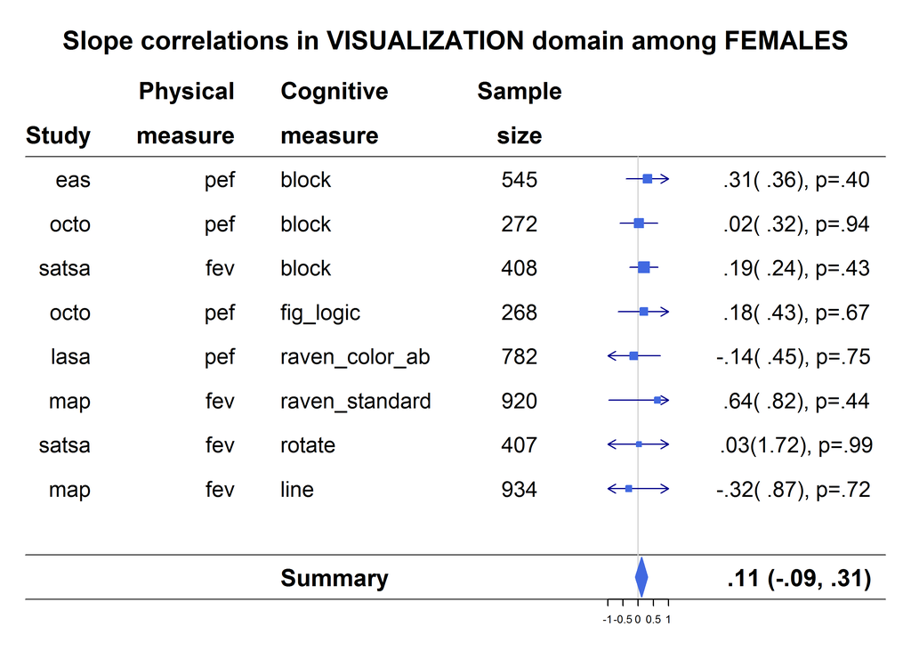

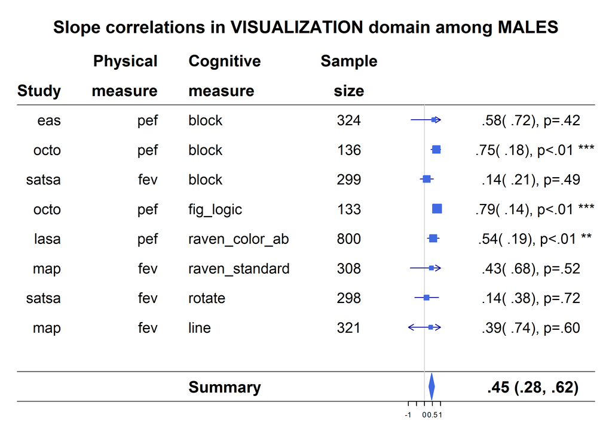

## perceptual speed

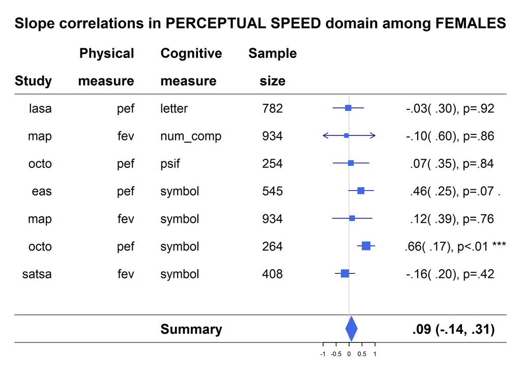

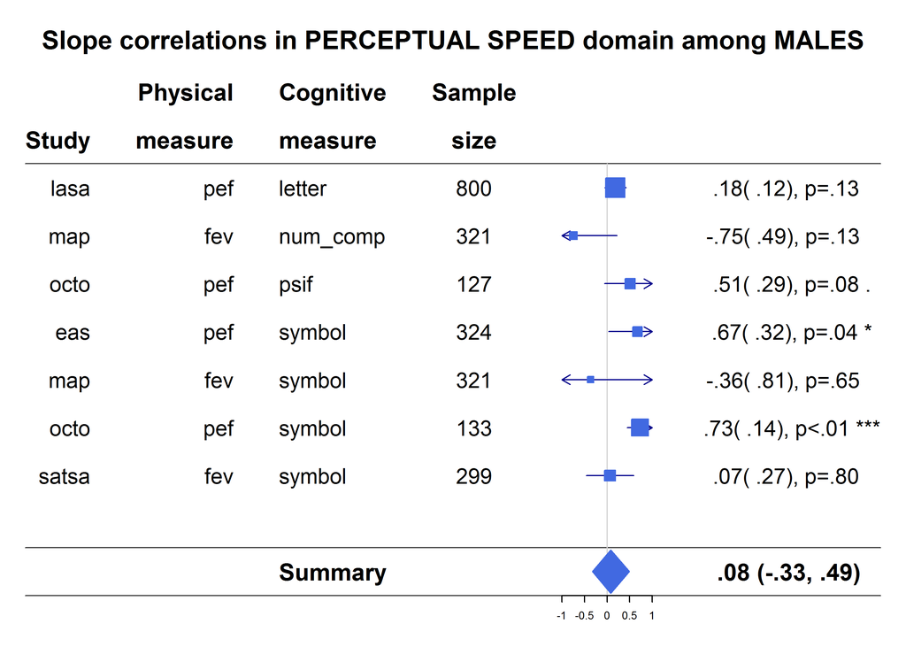

# Session Information

For the sake of documentation and reproducibility, the current report was rendered on a system using the following software.

```
Report rendered by koval_000 at 2017-02-15, 13:09 -0500
```